# Gráficos IV

Gabriela, Matheus, Vitor

02/05/2020

# Boxplot

Um boxplot é um tipo de gráfico que condensa muita informação, como a mediana, os demais quartis e observações atípicas. Ele é normalmente adequado quando queremos comparar distribuições de variáveis numéricas. Para fazê-lo, utilizamos o comando “boxplot()”. O nosso exemplo utilizará o banco de dados “tempo” que traz dados sobre o tempo no aeroporto de Raleigh, Carolina do Norte, EUA a cada dia em determinado período. Decidimos ver a distribuição da velocidade do vento. Veja que argumentos como main, col e ylab funcionam normalmente.

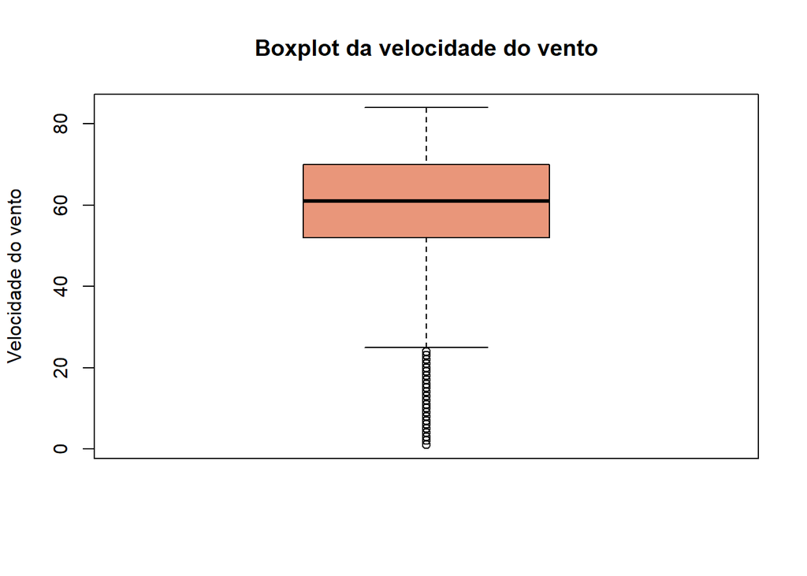

```r
library(exatas)
boxplot(as.numeric(tempo$avgwindspeed),main= "Boxplot da velocidade do vento",col="darksalmon", ylab="Velocidade do vento")
```

Também é possível fazer boxplots para a distribuição de uma variável númerica para cada valor de uma categórica. No R, basta fazer boxplot(numerica~categórica). Fizemos um exemplo cruzando a velocidade do vento com a presença ou não de chuva no dia. Nesse caso, podemos definir uma cor para cada um dos boxplot usando um vetor como valor do argumento “col”.

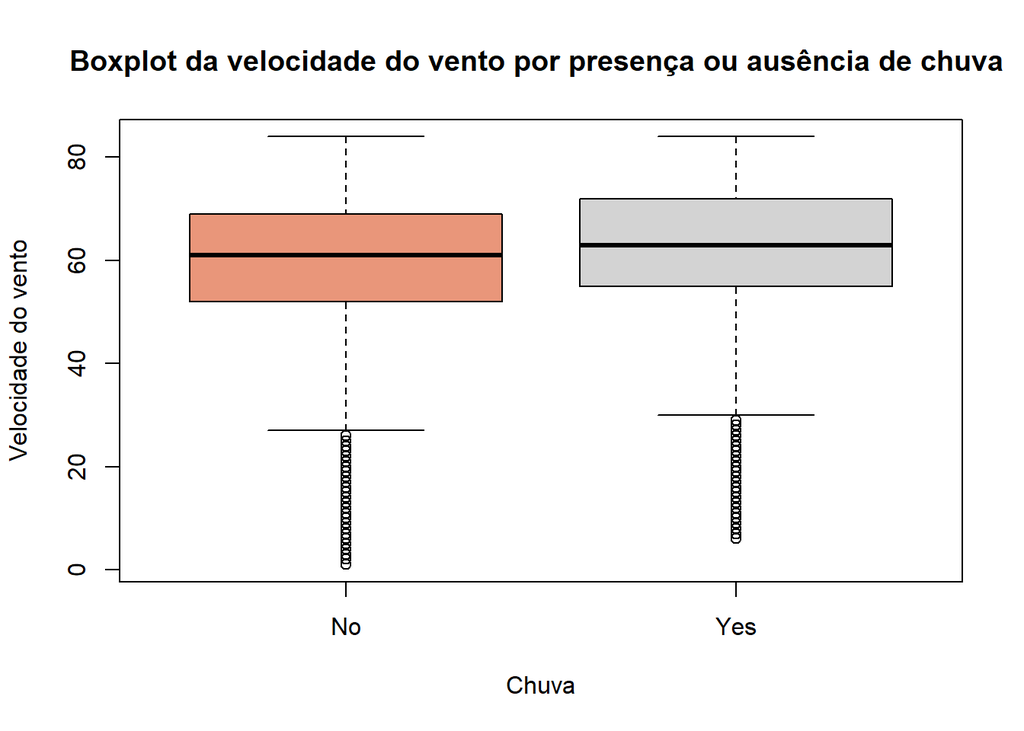

```r
boxplot(as.numeric(tempo$avgwindspeed)~tempo$rain,main= "Boxplot da velocidade do vento por presença ou ausência de chuva ",col=c("darksalmon", "lightgray"), ylab="Velocidade do vento",xlab="Chuva")
```

# Histograma

Um outro modo de avaliar a distribuição de uma variável numérica é um histograma, que mostra a frequência dela em classes de valores. Para fazê-lo no R, usamos o comando ‘hist()’. Aqui, faremos um histograma da temperatura máxima ocorrida em um dia no aeroporto de Raleigh (utilizando o banco de dados “tempo”). Argumentos como col, xlab,ylab e main são aceitos, assim como nos demais gráficos.

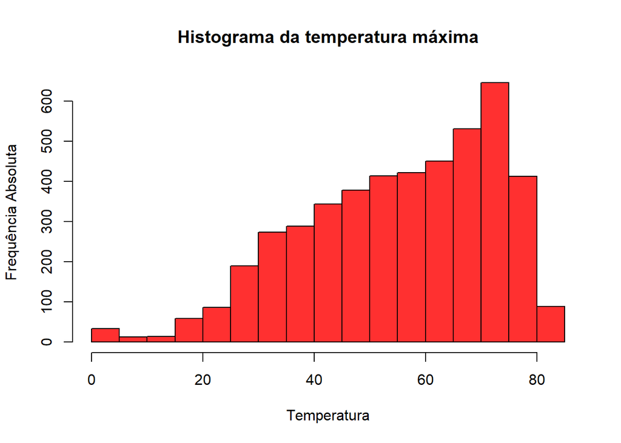

```r
hist(as.numeric(tempo$temperaturemax),col="firebrick1",xlab="Temperatura",ylab="Frequência Absoluta", main="Histograma da temperatura máxima")
```

Podemos também fazer um hsitograma com frequência relativa, colocando o valor FALSE no argumento “freq”.

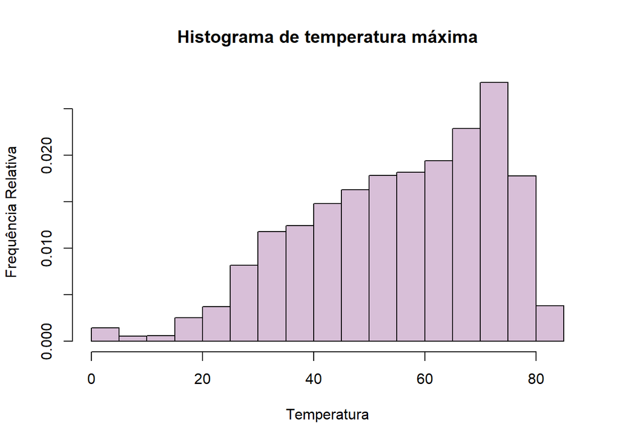

```r
hist(as.numeric(tempo$temperaturemax),col="thistle",xlab="Temperatura",ylab="Frequência Relativa",main= "Histograma de temperatura máxima",freq=FALSE)
```

Podemos alterar os limites dos intervalos a partir do parâmetro “breaks”. Nele, podemos colocar um número, que será definido como o número de classes, ou um vetor que delimite todos os pontos de quebra. Fazendo do primeiro modo:

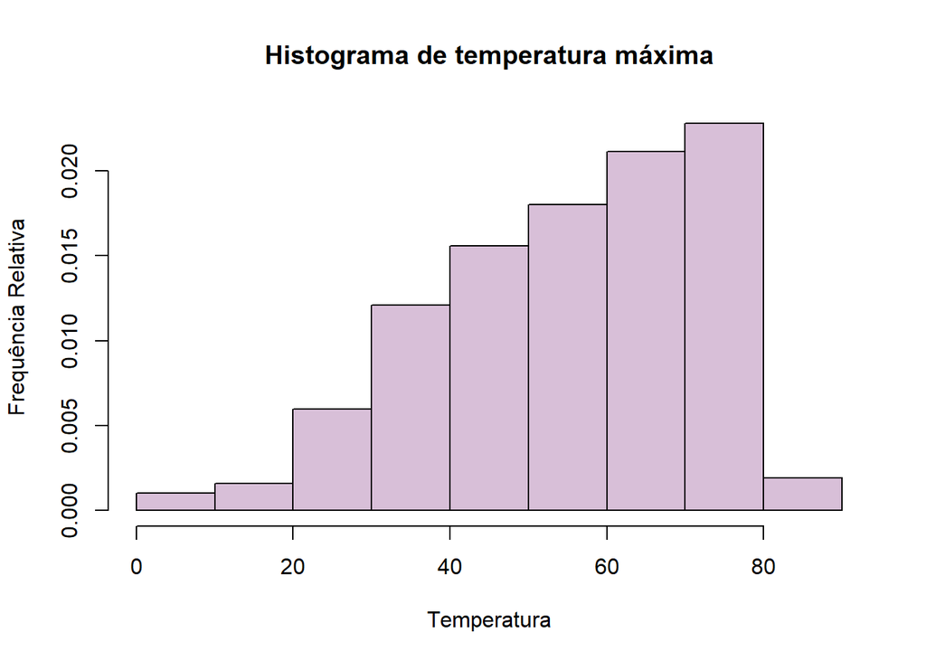

```r
hist(as.numeric(tempo$temperaturemax),col="thistle",xlab="Temperatura",ylab="Frequência Relativa",main= "Histograma de temperatura máxima",freq=FALSE,breaks=8)
```

Agora, usando um vetor com os limites:

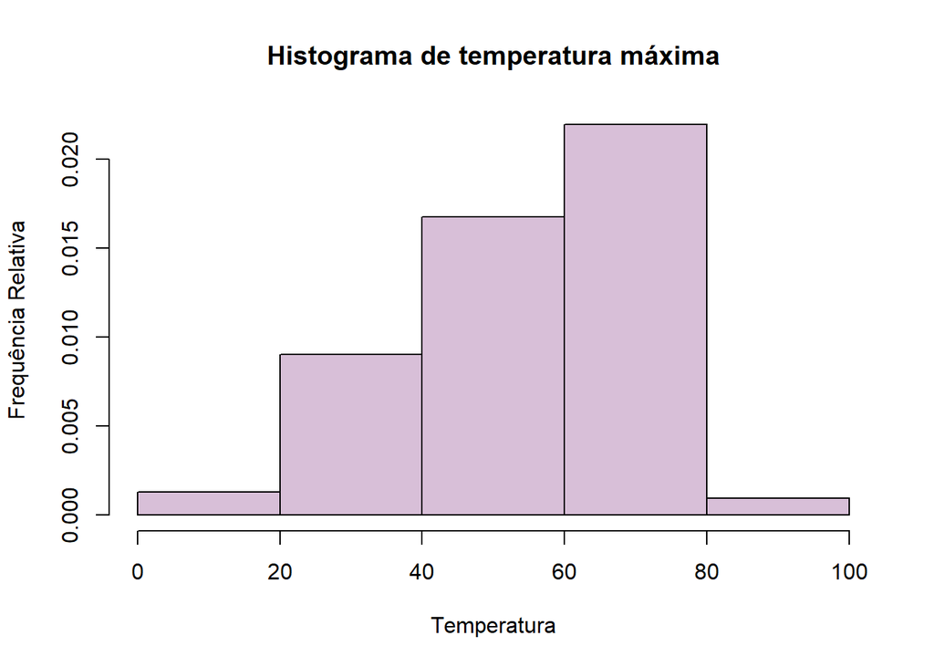

```r
hist(as.numeric(tempo$temperaturemax),col="thistle",xlab="Temperatura",ylab="Frequência Relativa",main= "Histograma de temperatura máxima",freq=FALSE,breaks=c(0,20,40,60,80,100))
```